# Pertemuan 2

Audryna Khairunnisa Wibisono (M0401241012)

# Pemanggilan Packages

```r
library(dplyr)
library(TTR)
library(forecast)
library(lmtest)
library(orcutt) #untuk membuat model regresi Cochrane-Orcutt
library(HoRM) #untuk membuat model regresi Hildreth-Lu
```

# Latihan Nomor 1 (Market Share & Price)

## Input Data

```r
library(rio)
dt1 <- import("https://raw.githubusercontent.com/audrynakhairunnisa/mpdw/main/Pertemuan%202/data_regresi_deret_waktu.xlsx")
dt1
```

```
##    Period Market share Price
## 1       1         3.63  0.97
## 2       2         4.20  0.95
## 3       3         3.33  0.99
## 4       4         4.54  0.91
## 5       5         2.89  0.98
## 6       6         4.87  0.90
## 7       7         4.90  0.89
## 8       8         5.29  0.86
## 9       9         6.18  0.85
## 10     10         7.20  0.82
## 11     11         7.25  0.79
## 12     12         6.09  0.83
## 13     13         6.80  0.81
## 14     14         8.65  0.77
## 15     15         8.43  0.76
## 16     16         8.29  0.80
## 17     17         7.18  0.83
## 18     18         7.90  0.79
## 19     19         8.45  0.76
## 20     20         8.23  0.78
```

## Eksplorasi Data

```r
#Membentuk Objek Time Series
dt1.ts<-ts(dt1$'Market share')
dt1.ts
```

```
## Time Series:
## Start = 1
## End = 20
## Frequency = 1
##  [1] 3.63 4.20 3.33 4.54 2.89 4.87 4.90 5.29 6.18 7.20 7.25 6.09 6.80 8.65 8.43
## [16] 8.29 7.18 7.90 8.45 8.23
```

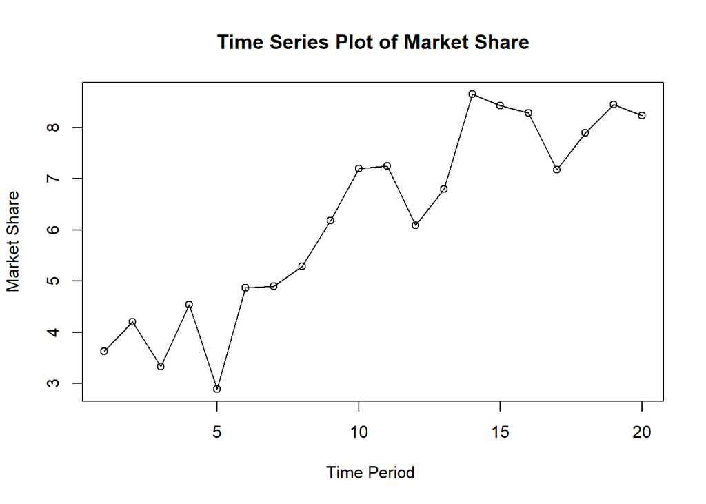

```r
#Membuat Plot Time Series
ts.plot(dt1.ts, xlab="Time Period ", ylab="Market Share", main= "Time Series Plot of Market Share")
points(dt1.ts)
```

Selanjutnya akan dilakukan ramalan dan pemulusan dengan metode DMA dan DES karena terlihat pada plot di atas menunjukkan adanya trend.

```r
dt.sma <- SMA(dt1.ts, n = 3)
dma <- SMA(dt.sma, n = 3)

At <- 2 * dt.sma - dma
Bt <- 2 / (3 - 1) * (dt.sma - dma)

dt.dma <- At + Bt
dt.ramal <- c(NA, dt.dma)

t <- 1:5
f <- c()

for (i in t) {
  f[i] <- At[length(At)] + Bt[length(Bt)] * i
}
```

```r
dt.gab <- cbind(aktual = c(dt1.ts, rep(NA, 5)),
                pemulusan1 = c(dt.sma, rep(NA, 5)),
                pemulusan2 = c(dt.dma, rep(NA, 5)),
                At = c(At, rep(NA, 5)),
                Bt = c(Bt, rep(NA, 5)),
                ramalan = c(dt.ramal, f[-1]))

dt.gab
```

```
##       aktual pemulusan1 pemulusan2       At          Bt  ramalan
##  [1,]   3.63         NA         NA       NA          NA       NA
##  [2,]   4.20         NA         NA       NA          NA       NA
##  [3,]   3.33   3.720000         NA       NA          NA       NA
##  [4,]   4.54   4.023333         NA       NA          NA       NA
##  [5,]   2.89   3.586667   3.206667 3.396667 -0.19000000       NA
##  [6,]   4.87   4.100000   4.493333 4.296667  0.19666667 3.206667
##  [7,]   4.90   4.220000   4.722222 4.471111  0.25111111 4.493333
##  [8,]   5.29   5.020000   6.166667 5.593333  0.57333333 4.722222
##  [9,]   6.18   5.456667   6.572222 6.014444  0.55777778 6.166667
## [10,]   7.20   6.223333   7.536667 6.880000  0.65666667 6.572222
## [11,]   7.25   6.876667   8.258889 7.567778  0.69111111 7.536667
## [12,]   6.09   6.846667   7.242222 7.044444  0.19777778 8.258889
## [13,]   6.80   6.713333   6.515556 6.614444 -0.09888889 7.242222
## [14,]   8.65   7.180000   7.713333 7.446667  0.26666667 6.515556
## [15,]   8.43   7.960000   9.311111 8.635556  0.67555556 7.713333
## [16,]   8.29   8.456667   9.638889 9.047778  0.59111111 9.311111
## [17,]   7.18   7.966667   7.644444 7.805556 -0.16111111 9.638889
## [18,]   7.90   7.790000   7.227778 7.508889 -0.28111111 7.644444
## [19,]   8.45   7.843333   7.796667 7.820000 -0.02333333 7.227778
## [20,]   8.23   8.193333   8.695556 8.444444  0.25111111 7.796667
## [21,]     NA         NA         NA       NA          NA 8.695556
## [22,]     NA         NA         NA       NA          NA 8.946667
## [23,]     NA         NA         NA       NA          NA 9.197778
## [24,]     NA         NA         NA       NA          NA 9.448889
## [25,]     NA         NA         NA       NA          NA 9.700000
```

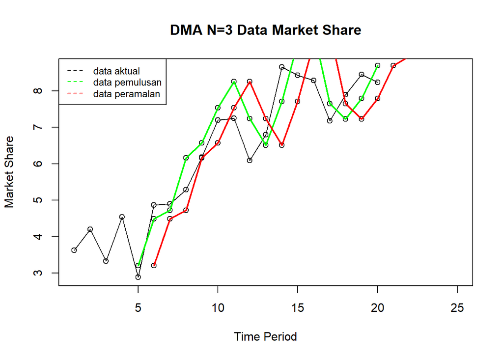

```r
# Plot Time Series
ts.plot(dt.gab[,1],
        xlab = "Time Period",
        ylab = "Market Share",
        main = "DMA N=3 Data Market Share")

points(dt.gab[,1])
points(dt.gab[,3])
points(dt.gab[,6])

lines(dt.gab[,3], col = "green", lwd = 2)
lines(dt.gab[,6], col = "red", lwd = 2)

legend("topleft",
       c("data aktual", "data pemulusan", "data peramalan"),
       lty = 8,
       col = c("black", "green", "red"),
       cex = 0.8)
```

Selanjutnya akan dilihat keakuratan dari metode DMA

```r
#Menghitung Nilai Keakuratan
error.dma = dt1.ts-dt.ramal[1:length(dt1.ts)]
SSE.dma = sum(error.dma[6:length(dt1.ts)]^2)
MSE.dma = mean(error.dma[6:length(dt1.ts)]^2)
MAPE.dma = mean(abs((error.dma[6:length(dt1.ts)]/dt1.ts[6:length(dt1.ts)])*100))

akurasi.dma <- matrix(c(SSE.dma, MSE.dma, MAPE.dma))
row.names(akurasi.dma)<- c("SSE", "MSE", "MAPE")
colnames(akurasi.dma) <- c("Akurasi m = 3")
akurasi.dma
```

```
##      Akurasi m = 3
## SSE       22.53571
## MSE        1.50238
## MAPE      14.05989
```

Selanjutnya akan digunakan metode Double Exponential Smoothing dengan cara sebagai berikut.

Pertama akan data akan dibagi menjadi data training dan data testing.

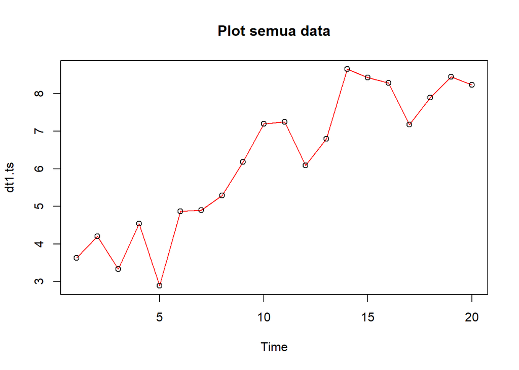

```r
#Membagi Training dan Testing
training<-dt1[1:10,2]
testing<-dt1[11:12,2]

#Data Time Series
training.ts<-ts(training)
testing.ts<-ts(testing,start=11)

#Eksplorasi Data
plot(dt1.ts, col="red",main="Plot semua data")
points(dt1.ts)
```

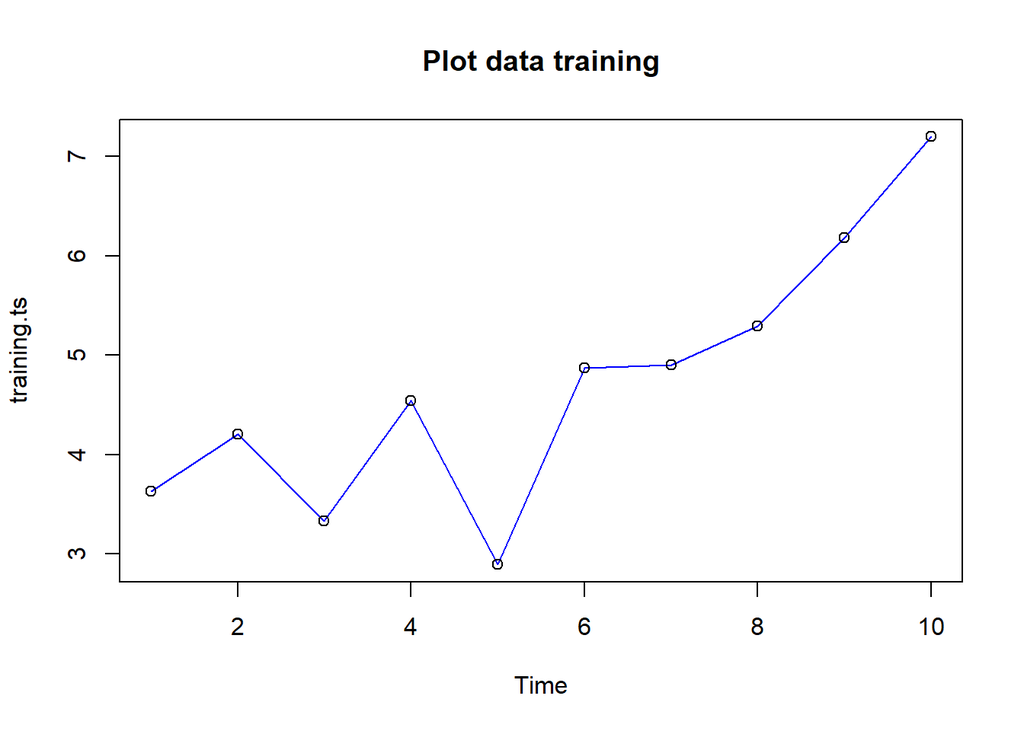

```r
plot(training.ts, col="blue",main="Plot data training")
points(training.ts)
```

Selanjutnya akan dilakukan pemulusan dengan DES, kali ini langsung dicari lambda dan gamma optimum sebagai berikut. Nilai lambda dan gamma optimum dapat dilihat pada smoothing parameters alpha untuk nilai lambda dan beta untuk nilai gamma.

```r
#Lamda dan Gamma Optimum
des.opt<- HoltWinters(training.ts, gamma = FALSE)
des.opt
```

```
## Holt-Winters exponential smoothing with trend and without seasonal component.
##
## Call:
## HoltWinters(x = training.ts, gamma = FALSE)
##
## Smoothing parameters:
##  alpha: 0.5836977
##  beta : 0.01866974
##  gamma: FALSE
##
## Coefficients:
##        [,1]
## a 6.9542708
## b 0.5402764
```

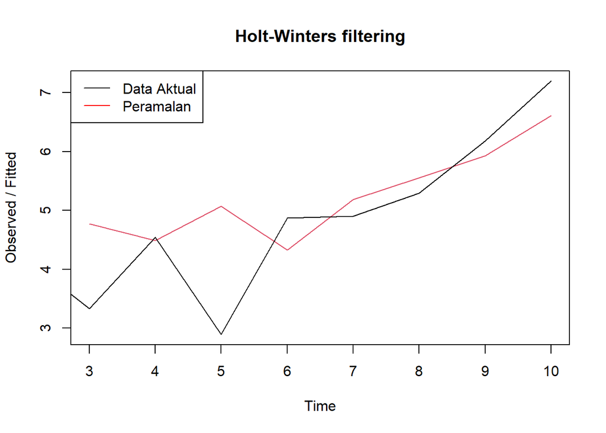

```r
plot(des.opt)
legend("topleft", c("Data Aktual", "Peramalan"), col = c("black", "red"),
       lty = c(1,1), cex = 1)
```

```r
#Ramalan
ramalandesopt<- forecast(des.opt, h=5)
ramalandesopt
```

```
##    Point Forecast    Lo 80     Hi 80    Lo 95     Hi 95
## 11       7.494547 6.235444  8.753650 5.568915  9.420179
## 12       8.034824 6.569959  9.499688 5.794507 10.275140
## 13       8.575100 6.923723 10.226478 6.049536 11.100664
## 14       9.115376 7.290718 10.940035 6.324803 11.905950
## 15       9.655653 7.667389 11.643917 6.614866 12.696440
```

Selanjutnya akan dicari akurasi dari metode DES.

```r
ssedes.train<-des.opt$SSE
msedes.train<-ssedes.train/length(training.ts)
sisaandes<-ramalandesopt$residuals
head(sisaandes)
```

```
## Time Series:
## Start = 1
## End = 6
## Frequency = 1
## [1]          NA          NA -1.44000000  0.05621705 -2.18151696  0.54068225
```

```r
mapedes.train <- sum(abs(sisaandes[3:length(training.ts)]/training.ts[3:length(training.ts)])*100)/length(training.ts)

akurasides.opt <- matrix(c(ssedes.train,msedes.train,mapedes.train))
row.names(akurasides.opt)<- c("SSE", "MSE", "MAPE")
colnames(akurasides.opt) <- c("Akurasi lamda dan gamma optimum")
akurasides.opt
```

```
##      Akurasi lamda dan gamma optimum
## SSE                        7.6868673
## MSE                        0.7686867
## MAPE                      15.4008083
```

```r
#Akurasi Data Testing
selisihdesopt<-ramalandesopt$mean-testing.ts
selisihdesopt
```

```
## Time Series:
## Start = 11
## End = 12
## Frequency = 1
## [1] 0.2445472 1.9448236
```

```r
SSEtestingdesopt<-sum(selisihdesopt^2)
SSEtestingdesopt<-SSEtestingdesopt/length(testing.ts)
MAPEtestingdesopt<-sum(abs(selisihdesopt/testing.ts)*100)/length(testing.ts)

akurasiDesTesting <- matrix(c(SSEtestingdesopt,SSEtestingdesopt,MAPEtestingdesopt))
row.names(akurasiDesTesting)<- c("SSE", "MSE", "MAPE")
colnames(akurasiDesTesting) <- c("Akurasi lamda dan gamma optimum")
akurasiDesTesting
```

```
##      Akurasi lamda dan gamma optimum
## SSE                         1.921071
## MSE                         1.921071
## MAPE                       17.653886
```

Setelah didapatkan nilai akurasi untuk metode DMA dan DES, selanjutnya akan dibandingkan keakuratan antar metode keduanya.

```r
cbind(akurasi.dma, akurasides.opt)
```

```
##      Akurasi m = 3 Akurasi lamda dan gamma optimum
## SSE       22.53571                       7.6868673
## MSE        1.50238                       0.7686867
## MAPE      14.05989                      15.4008083
```

Berdasarkan perbandingan akurasi tersebut, terlihat nilai SSE dan MSE metode DES lebih kecil dibandingkan dengan metode DMA, sedangkan nilai MAPE metode DMA lebih kecil dibandingkan dengan metode DES. Oleh karena itu, metode peramalan dan pemulusan yang terbaik antara keduanya adalah **metode DES**, karena memiliki nilai SSE dan MSE yang lebih kecil.

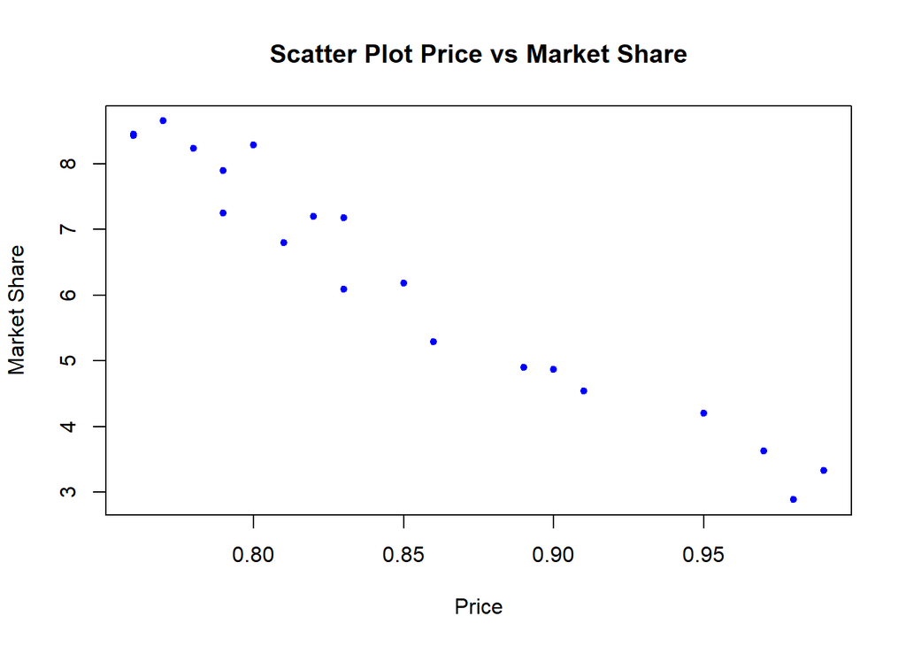

```r
#Eksplorasi Data
#Pembuatan Scatter Plot
plot(dt1$Price,dt1$'Market share', pch = 20, col = "blue",
     main = "Scatter Plot Price vs Market Share",
     xlab = "Price",
     ylab = "Market Share")
```

```r
#Menampilkan Nilai Korelasi
cor(dt1$Price,dt1$'Market share')
```

```
## [1] -0.9752564
```

Berdasarkan scatter plot di atas, terlihat adanya hubungan / korelasi negatif kuat antara Price dengan Market Share, terlihat titik-titik pada plot yang cenderung menurun ke arah kanan bawah. Hal tersebut juga diperkuat dengan hasil perhitungan aplikasi R di mana didapatkan nilai korelasi sebesar -0.9752564.

Setalah mengetahui adanya hubungan antar dua peubah, maka model regresi dapat ditentukan.

## Regresi

```r
#Pembuatan Model Regresi
#Model Regresi
model<- lm(`Market share` ~ Price, data = dt1)
summary(model)
```

```
##
## Call:
## lm(formula = `Market share` ~ Price, data = dt1)
##
## Residuals:
##      Min       1Q   Median       3Q      Max
## -0.73068 -0.29764 -0.00966  0.30224  0.81193
##
## Coefficients:
##             Estimate Std. Error t value Pr(>|t|)
## (Intercept)   26.910      1.110   24.25 3.39e-15 ***
## Price        -24.290      1.298  -18.72 3.02e-13 ***
## ---
## Signif. codes:  0 '***' 0.001 '**' 0.01 '*' 0.05 '.' 0.1 ' ' 1
##
## Residual standard error: 0.4287 on 18 degrees of freedom
## Multiple R-squared:  0.9511, Adjusted R-squared:  0.9484
## F-statistic: 350.3 on 1 and 18 DF,  p-value: 3.019e-13
```

Model yang dihasilkan adalah
$$y_i=26.910-24.290x_i$$
Berdasarkan ringkasan model dapat diketahui bahwa hasil uji F memiliki *p-value* < $\alpha$ (5%). Artinya, minimal terdapat satu variabel yang berpengaruh nyata terhadap model. Hasil uji-t parsial kedua parameter regresi, yaitu intersep dan koefisien regresi juga menunjukkan hal yang sama, yaitu memiliki *p-value* < $\alpha$ (5%) sehingga nyata dalam taraf 5%. Selanjutnya dapat dilihat juga nilai $R^2=0.9511$. Artinya, sebesar 95.11% keragaman nilai Market Share dapat dijelaskan oleh peubah Price. Hasil ini menunjukkan hasil yang bagus, seolah mendapatkan hasil terbaik. Namun, kita perlu melakukan uji terhadap sisaannya seperti berikut ini.

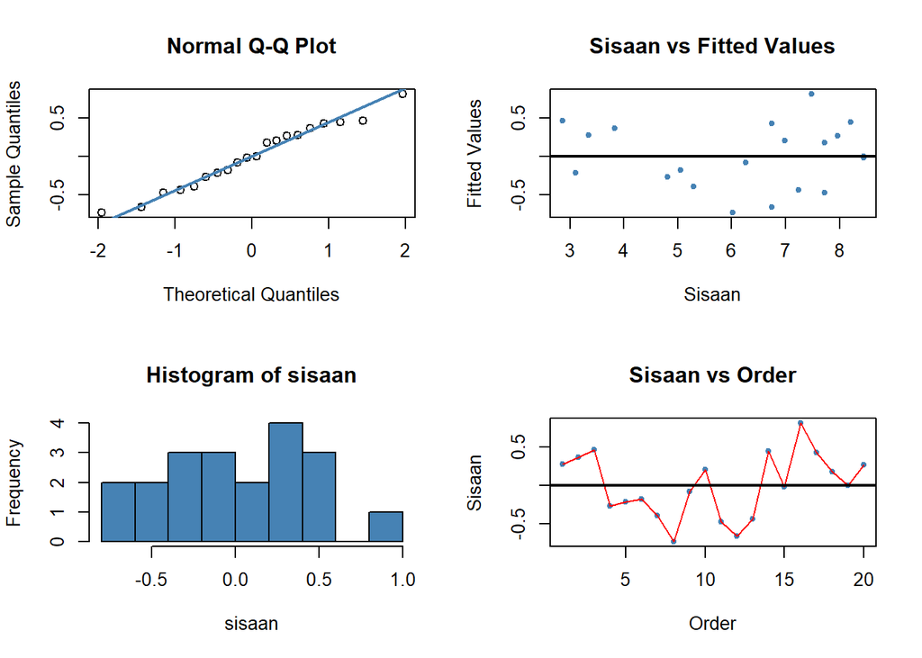

```r
#Sisaan dan Fitted Value
sisaan<- residuals(model)
fitValue<- predict(model)

#Diagnostik dengan Eksploratif
par(mfrow = c(2,2))
qqnorm(sisaan)
qqline(sisaan, col = "steelblue", lwd = 2)
plot(fitValue, sisaan, col = "steelblue", pch = 20, xlab = "Sisaan", ylab = "Fitted Values", main = "Sisaan vs Fitted Values")
abline(a = 0, b = 0, lwd = 2)
hist(sisaan, col = "steelblue")
plot(1:length(sisaan), sisaan, col = "steelblue", pch = 20, xlab = "Order", ylab = "Sisaan", main = "Sisaan vs Order")
lines(1:length(sisaan), sisaan, col = "red")
abline(a = 0, b = 0, lwd = 2)
```

Dua plot di samping kiri digunakan untuk melihat apakah sisaan menyebar normal. Normal Q-Q Plot di atas menunjukkan bahwa sisaan cenderung menyebar normal, tetapi histogram dari sisaan tidak menunjukkan demikian. Selanjutnya, dua plot di samping kanan digunakan untuk melihat autokorelasi. Plot Sisaan vs *Fitted Value* dan Plot Sisaan vs *Order* menunjukkan adanya pola pada sisaan. Untuk lebih lanjut akan digunakan uji formal melihat normalitas sisaan dan plot ACF dan PACF untuk melihat apakah ada autokorelasi atau tidak.

```r
#Melihat Sisaan Menyebar Normal/Tidak
#H0: sisaan mengikuti sebaran normal
#H1: sisaan tidak mengikuti sebaran normal
shapiro.test(sisaan)
```

```
##
##  Shapiro-Wilk normality test
##
## data:  sisaan
## W = 0.9744, p-value = 0.8437
```

```r
ks.test(sisaan, "pnorm", mean=mean(sisaan), sd=sd(sisaan))
```

```
##
##  Exact one-sample Kolmogorov-Smirnov test
##
## data:  sisaan
## D = 0.11606, p-value = 0.9222
## alternative hypothesis: two-sided
```

Berdasarkan uji formal Saphiro-Wilk dan Kolmogorov-Smirnov didapatkan nilai *p-value* > $\alpha$ (5%). Artinya, cukup bukti untuk menyatakan sisaan berdistribusi normal.

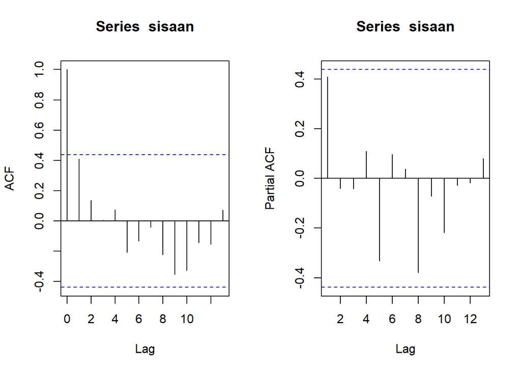

```r
#ACF dan PACF Identifikasi Autokorelasi
par(mfrow = c(1,2))
acf(sisaan)
pacf(sisaan)
```

Berdasarkan plot ACF dan PACF, terlihat semua dalam rentang batas dan tidak ada lag yang signifikan. Namun, untuk lebih memastikan akan dilakukan uji formal dengan uji Durbin Watson.

```r
#Deteksi Autokorelasi dengan Uji-Durbin Watson
#H0: tidak ada autokorelasi
#H1: ada autokorelasi
dwtest(model)
```

```
##
##  Durbin-Watson test
##
## data:  model
## DW = 1.1358, p-value = 0.009813
## alternative hypothesis: true autocorrelation is greater than 0
```

Berdasarkan hasil DW Test, didapatkan nilai $DW = 1.1358$ dan *p-value* = $0.009813$. Berdasarkan tabel Durbin-Watson diperoleh nilai $DL = 1.2015$ dan $DU = 1.4107$. Nilai DW berada di bawah nilai DL (0 < $DW = 1.1358$ < $DL = 1.2015$). Berdasarkan kriteria Durbin-Watson dapat disimpulkan bahwa terdapat autokorelasi positif. Namun, dengan nilai *p-value* < 0.05 dapat disimpulkan bahwa tolak H0, sehingga terdapat cukup bukti untuk mengatakan adanya autokorelasi. Oleh karena itu, diperlukan penanganan autokorelasi. Penanganan yang akan digunakan menggunakan dua metode, yaitu Cochrane-Orcutt dan Hildret-Lu.

## Penanganan Autokorelasi

### Metode Cochrane-Orcutt

Penanganan metode Cochrane-Orcutt dapat dilakukan dengan bantuan packages Orcutt pada aplikasi `R` maupun secara manual. Berikut ini ditampilkan cara menggunakan bantuan `library` *packages* `Orcutt`.

```r
#Penanganan Autokorelasi Cochrane-Orcutt
modelCO<-cochrane.orcutt(model)
modelCO
```

```
## Cochrane-orcutt estimation for first order autocorrelation
##
## Call:
## lm(formula = `Market share` ~ Price, data = dt1)
##
##  number of interaction: 8
##  rho 0.425232
##
## Durbin-Watson statistic
## (original):    1.13582 , p-value: 9.813e-03
## (transformed): 1.95804 , p-value: 4.151e-01
##
##  coefficients:
## (Intercept)       Price
##    26.72209   -24.08413
```

Hasil keluaran model setelah dilakukan penanganan adalah sebagai berikut.
$$y_i=26.72209-24.08413x_i$$
Hasil juga menunjukkan bahwa nilai DW dan p-value meningkat menjadi $1.95804$ dan $0.4151$. Nilai DW sudah berada pada rentang DU < DW < 4-DU atau $1.4107 < DW < 2.5893$. Hal tersebut juga didukung dengan nilai *p-value* > 0.05, artinya belum cukup bukti untuk menyatakan bahwa terdapat autokorelasi pada sisaan pada taraf nyata 5%. Untuk nilai $ρ ̂$ optimum yang digunakan adalah $0.425232$. Nilai tersebut dapat diketahui dengan *syntax* berikut.

```r
#Rho Optimum
rho<- modelCO$rho
rho
```

```
## [1] 0.4252321
```

Selanjutnya akan dilakukan transformasi secara manual dengan syntax berikut ini.

```r
dt1$`Market share`
```

```
##  [1] 3.63 4.20 3.33 4.54 2.89 4.87 4.90 5.29 6.18 7.20 7.25 6.09 6.80 8.65 8.43
## [16] 8.29 7.18 7.90 8.45 8.23
```

```r
dt1$`Market share`[-1]
```

```
##  [1] 4.20 3.33 4.54 2.89 4.87 4.90 5.29 6.18 7.20 7.25 6.09 6.80 8.65 8.43 8.29
## [16] 7.18 7.90 8.45 8.23
```

```r
#Transformasi Manual
market.trans <- dt1$`Market share`[-1] -
                dt1$`Market share`[-length(dt1$`Market share`)] * rho
price.trans <- dt1$Price[-1] -
               dt1$Price[-length(dt1$Price)] * rho

modelCOmanual <- lm(market.trans ~ price.trans)
summary(modelCOmanual)
```

```
##
## Call:
## lm(formula = market.trans ~ price.trans)
##
## Residuals:
##      Min       1Q   Median       3Q      Max
## -0.55508 -0.25069 -0.05506  0.25007  0.83017
##
## Coefficients:
##             Estimate Std. Error t value Pr(>|t|)
## (Intercept)  15.3590     0.9385   16.36 7.71e-12 ***
## price.trans -24.0841     1.9385  -12.42 5.90e-10 ***
## ---
## Signif. codes:  0 '***' 0.001 '**' 0.01 '*' 0.05 '.' 0.1 ' ' 1
##
## Residual standard error: 0.3955 on 17 degrees of freedom
## Multiple R-squared:  0.9008, Adjusted R-squared:  0.895
## F-statistic: 154.4 on 1 and 17 DF,  p-value: 5.903e-10
```

```r
#Mencari Penduga Koefisien Regresi setelah Transformasi ke Persamaan Awal
b0bintang <- modelCOmanual$coefficients[-2]
b0 <- b0bintang/(1-rho)
b1 <- modelCOmanual$coefficients[-1]
b0
```

```
## (Intercept)
##    26.72209
```

```r
b1
```

```
## price.trans
##   -24.08413
```

Hasil perhitungan koefisien regresi tersebut akan menghasilkan hasil yang sama dengan model yang dihasilkan menggunakan *packages*.

### Metode Hildreth-Lu

Penanganan kedua adalah menggunakan metode Hildreth-Lu. Metode ini akan mencari nilai SSE terkecil dan dapat dicari secara manual maupun menggunakan packages. Jika menggunakan packages, gunakan `library` *packages* `HORM`.

```r
library(HoRM)

#Ambil y dan x (satu prediktor saja)
y <- dt1$`Market share`
x <- dt1$Price

#Grid search rho 0–0.9
r <- seq(0, 0.9, by = 0.1)
tab <- data.frame(
  rho = r,
  SSE = sapply(r, function(rr) deviance(hildreth.lu(y, x, rr)))
)

tab            # Tabel rho vs SSE
```

```
##    rho      SSE
## 1  0.0 3.212112
## 2  0.1 2.979074
## 3  0.2 2.810498
## 4  0.3 2.705239
## 5  0.4 2.661188
## 6  0.5 2.674924
## 7  0.6 2.741983
## 8  0.7 2.858804
## 9  0.8 3.026489
## 10 0.9 3.252863
```

```r
rho_hat <- tab$rho[which.min(tab$SSE)]   # Rho terbaik
fit_hl  <- hildreth.lu(y, x, rho_hat)    # Model final
summary(fit_hl)
```

```
##
## Call:
## lm(formula = y ~ x)
##
## Residuals:
##      Min       1Q   Median       3Q      Max
## -0.56476 -0.24781 -0.05422  0.25392  0.82998
##
## Coefficients:
##             Estimate Std. Error t value Pr(>|t|)
## (Intercept)   16.070      0.957   16.79 5.10e-12 ***
## x            -24.158      1.892  -12.77 3.88e-10 ***
## ---
## Signif. codes:  0 '***' 0.001 '**' 0.01 '*' 0.05 '.' 0.1 ' ' 1
##
## Residual standard error: 0.3957 on 17 degrees of freedom
## Multiple R-squared:  0.9055, Adjusted R-squared:    0.9
## F-statistic:   163 on 1 and 17 DF,  p-value: 3.88e-10
```

```r
#Penanganan Autokorelasi Hildreth Lu
# Hildreth-Lu
hildreth.lu.func<- function(r, model){
  x <- model.matrix(model)[,-1]
  y <- model.response(model.frame(model))
  n <- length(y)
  t <- 2:n
  y <- y[t]-r*y[t-1]
  x <- x[t]-r*x[t-1]

  return(lm(y~x))
}

#Pencarian Rho yang Meminimumkan SSE
r <- c(seq(0.1,0.9, by= 0.1))
tab <- data.frame("rho" = r, "SSE" = sapply(r, function(i){deviance(hildreth.lu.func(i, model))}))
round(tab, 4)
```

```
##   rho    SSE
## 1 0.1 2.9791
## 2 0.2 2.8105
## 3 0.3 2.7052
## 4 0.4 2.6612
## 5 0.5 2.6749
## 6 0.6 2.7420
## 7 0.7 2.8588
## 8 0.8 3.0265
## 9 0.9 3.2529
```

Pertama-tama akan dicari di mana kira-kira $ρ$ yang menghasilkan SSE minimum. Pada hasil di atas terlihat $ρ$ minimum ketika 0.4. Namun, hasil tersebut masih kurang teliti sehingga akan dicari kembali $ρ$ yang lebih optimum dengan ketelitian yang lebih. Jika sebelumnya jarak antar $ρ$ yang dicari adalah 0.1, kali ini jarak antar $ρ$ adalah 0.001 dan dilakukan pada selang 0.2 sampai dengan 0.5.

```r
#Rho Optimal di Sekitar 0.4
rOpt <- seq(0.2,0.5, by= 0.001)
tabOpt <- data.frame("rho" = rOpt, "SSE" = sapply(rOpt, function(i){deviance(hildreth.lu.func(i, model))}))
head(tabOpt[order(tabOpt$SSE),])
```

```
##       rho      SSE
## 226 0.425 2.659368
## 227 0.426 2.659370
## 225 0.424 2.659372
## 228 0.427 2.659377
## 224 0.423 2.659382
## 229 0.428 2.659390
```

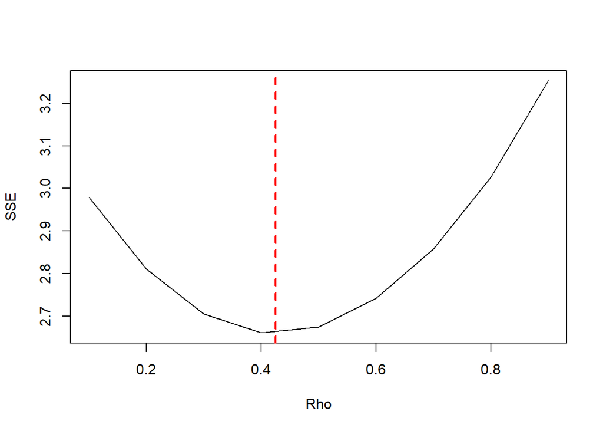

```r
#Grafik SSE Optimum
par(mfrow = c(1,1))
plot(tab$SSE ~ tab$rho , type = "l", xlab = "Rho", ylab = "SSE")
abline(v = tabOpt[tabOpt$SSE==min(tabOpt$SSE),"rho"], lty = 2, col="red",lwd=2)
text(x=0.341, y=0.2397500, labels = "rho=0.341", cex = 0.8)
```

Perhitungan yang dilakukan aplikasi `R` menunjukkan bahwa nilai $ρ$ optimum, yaitu saat SSE terkecil terdapat pada nilai $ρ=0.425$. Hal tersebut juga ditunjukkan pada plot. Selanjutnya, model dapat didapatkan dengan mengevaluasi nilai $ρ$ ke dalam fungsi `hildreth.lu.func`, serta dilanjutkan dengan pengujian autokorelasi dengan uji Durbin-Watson. Namun, setelah pengecekan tersebut tidak lupa koefisien regresi tersebut digunakan untuk transformasi balik. Persamaan hasil transformasi itulah yang menjadi persamaan sesungguhnya.

```r
#Model Terbaik
modelHL <- hildreth.lu.func(0.425, model)
summary(modelHL)
```

```
##
## Call:
## lm(formula = y ~ x)
##
## Residuals:
##      Min       1Q   Median       3Q      Max
## -0.55517 -0.25066 -0.05505  0.25010  0.83017
##
## Coefficients:
##             Estimate Std. Error t value Pr(>|t|)
## (Intercept)  15.3655     0.9387   16.37 7.68e-12 ***
## x           -24.0848     1.9380  -12.43 5.88e-10 ***
## ---
## Signif. codes:  0 '***' 0.001 '**' 0.01 '*' 0.05 '.' 0.1 ' ' 1
##
## Residual standard error: 0.3955 on 17 degrees of freedom
## Multiple R-squared:  0.9008, Adjusted R-squared:  0.895
## F-statistic: 154.4 on 1 and 17 DF,  p-value: 5.88e-10
```

```r
#Transformasi Balik
cat("y = ", coef(modelHL)[1]/(1-0.425), "+", coef(modelHL)[2],"x", sep = "")
```

```
## y = 26.72268+-24.08484x
```

Setelah dilakukan tranformasi balik, didapatkan model dengan metode Hildreth-Lu sebagai berikut.
$$y_i=26.72268+(-24.08484)x_i$$

```r
#Deteksi Autokorelasi
dwtest(modelHL)
```

```
##
##  Durbin-Watson test
##
## data:  modelHL
## DW = 1.9577, p-value = 0.4148
## alternative hypothesis: true autocorrelation is greater than 0
```

Hasil uji Durbin-Watson juga menunjukkan bawah nilai DW sebesar $1.9577$ berada pada selang daerah tidak ada autokorelasi, yaitu pada rentang DU < DW < 4-DU atau $1.4107 < DW < 2.5893$. Hal tersebut juga didukung oleh *p-value* sebesar $0.4148$, di mana *p-value* > $\alpha$=5%. Artinya tak tolak $H_0$ atau belum cukup bukti menyatakan bahwa ada autokorelasi dalam data nilai Market Share dengan metode Hildreth-Lu pada taraf nyata 5%.

Terakhir, akan dibandingkan nilai SSE dari ketiga metode (metode awal, metode Cochrane-Orcutt, dan Hildreth-Lu).

```r
#Perbandingan
sseModelawal <- anova(model)$`Sum Sq`[-1]
sseModelCO <- anova(modelCOmanual)$`Sum Sq`[-1]
sseModelHL <- anova(modelHL)$`Sum Sq`[-1]
mseModelawal <- sseModelawal/length(dt1$`Market share`)
mseModelCO <- sseModelCO/length(dt1$`Market share`)
mseModelHL <- sseModelHL/length(dt1$`Market share`)
akurasi <- matrix(c(sseModelawal, sseModelCO, sseModelHL,
                    mseModelawal, mseModelCO, mseModelHL),
                  nrow=2, ncol=3, byrow=T)
colnames(akurasi) <- c("Model Awal", "Model Cochrane-Orcutt", "Model Hildreth-Lu")
row.names(akurasi) <- c("SSE","MSE")
akurasi
```

```
##     Model Awal Model Cochrane-Orcutt Model Hildreth-Lu
## SSE  3.3082574             2.6593681         2.6593683
## MSE  0.1654129             0.1329684         0.1329684
```

Berdasarkan hasil tersebut dapat diketahui bahwa hasil penanganan autokorelasi dengan metode Cochrane-Orcutt dan Hildreth-Lu memiliki SSE yang hampir sama, yaitu masing-masing sebesar $2.6593681$ dan $2.6593683$, serta lebih baik dibandingkan model awal ketika autokorelasi masih terjadi, yaitu sebesar $3.3082574$.

## Simpulan

Autokorelasi yang terdapat pada data Market Share terjadi akibat adanya korelasi di antara unsur penyusunnya. Indikator Market Share yang erat hubungannya dengan perekonomian sangat rawan menjadi penyebab adanya autokorelasi. Adanya autokorelasi menyebabkan model regresi kurang baik karena akan meningkatkan galatnya. Autokorelasi dapat dideteksi secara eksploratif melalui plot sisaan, ACF, dan PACF, serta dengan uji formal Durbin-Watson. Namun, autokorelasi tersebut dapat ditangani dengan metode Cochrane-Orcutt dan Hildreth-Lu. Kedua metode menghasilkan nilai SSE yang hampir sama, sehingga keduanya dapat digunakan untuk menangani autokorelasi pada data.

# Latihan Nomor 2 (Sales & Advertising)

## Input Data

```r
library(rio)
dt2 <- import("https://raw.githubusercontent.com/audrynakhairunnisa/mpdw/main/Pertemuan%202/Sales_Advertising_Data.xlsx")
dt2
```

```
##    Year Sales Advertising
## 1  1975  11.7         9.4
## 2  1976  12.0         9.6
## 3  1977  12.3        10.0
## 4  1978  12.8        10.4
## 5  1979  13.1        10.8
## 6  1980  13.6        10.9
## 7  1981  13.9        11.7
## 8  1982  14.4        12.2
## 9  1983  14.7        12.5
## 10 1984  15.3        12.9
## 11 1985  15.5        13.0
## 12 1986  15.8        13.2
## 13 1987  16.1        13.8
## 14 1988  16.6        14.2
```

[output cut: 26 more lines]

## Eksplorasi Data

```r
#Membentuk Objek Time Series
dt2.ts<-ts(dt2$Sales)
dt2.ts
```

```
## Time Series:
## Start = 1
## End = 40
## Frequency = 1
##  [1] 11.7 12.0 12.3 12.8 13.1 13.6 13.9 14.4 14.7 15.3 15.5 15.8 16.1 16.6 16.9
## [16] 16.7 16.9 17.4 17.6 17.9 18.0 17.9 18.0 18.2 18.2 18.3 18.6 19.2 19.3 19.5
## [31] 19.2 19.3 19.5 20.0 20.0 19.9 19.8 19.9 20.2 21.0
```

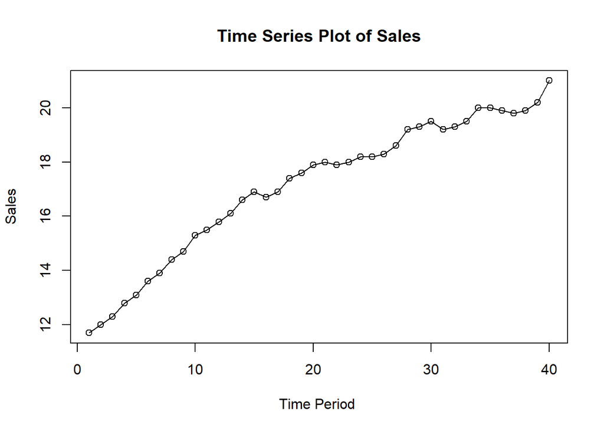

```r
#Membuat Plot Time Series
ts.plot(dt2.ts, xlab="Time Period ", ylab="Sales", main= "Time Series Plot of Sales")
points(dt2.ts)
```

Selanjutnya akan dilakukan ramalan dan pemulusan dengan metode DMA dan DES karena terlihat pada plot di atas menunjukkan adanya trend.

```r
dt2.sma <- SMA(dt2.ts, n = 3)
dma2 <- SMA(dt2.sma, n = 3)

At2 <- 2 * dt2.sma - dma2
Bt2 <- 2 / (3 - 1) * (dt2.sma - dma2)

dt2.dma <- At2 + Bt2
dt2.ramal <- c(NA, dt2.dma)

t2 <- 1:5
f2 <- c()

for (i in t2) {
  f2[i] <- At2[length(At2)] + Bt2[length(Bt2)] * i
}
```

```r
dt2.gab <- cbind(
  aktual = c(dt2.ts, rep(NA, 5)),
  pemulusan1 = c(dt2.sma, rep(NA, 5)),
  pemulusan2 = c(dt2.dma, rep(NA, 5)),
  At = c(At2, rep(NA, 5)),
  Bt = c(Bt2, rep(NA, 5)),
  ramalan = c(dt2.ramal, f2[-1])
)

dt2.gab
```

```
##       aktual pemulusan1 pemulusan2       At            Bt  ramalan
##  [1,]   11.7         NA         NA       NA            NA       NA
##  [2,]   12.0         NA         NA       NA            NA       NA
##  [3,]   12.3   12.00000         NA       NA            NA       NA
##  [4,]   12.8   12.36667         NA       NA            NA       NA
##  [5,]   13.1   12.73333   13.46667 13.10000  3.666667e-01       NA
##  [6,]   13.6   13.16667   13.98889 13.57778  4.111111e-01 13.46667
##  [7,]   13.9   13.53333   14.31111 13.92222  3.888889e-01 13.98889
##  [8,]   14.4   13.96667   14.78889 14.37778  4.111111e-01 14.31111
##  [9,]   14.7   14.33333   15.11111 14.72222  3.888889e-01 14.78889
## [10,]   15.3   14.80000   15.66667 15.23333  4.333333e-01 15.11111
## [11,]   15.5   15.16667   15.96667 15.56667  4.000000e-01 15.66667
## [12,]   15.8   15.53333   16.26667 15.90000  3.666667e-01 15.96667
## [13,]   16.1   15.80000   16.40000 16.10000  3.000000e-01 16.26667
## [14,]   16.6   16.16667   16.83333 16.50000  3.333333e-01 16.40000
```

[output cut: 31 more lines]

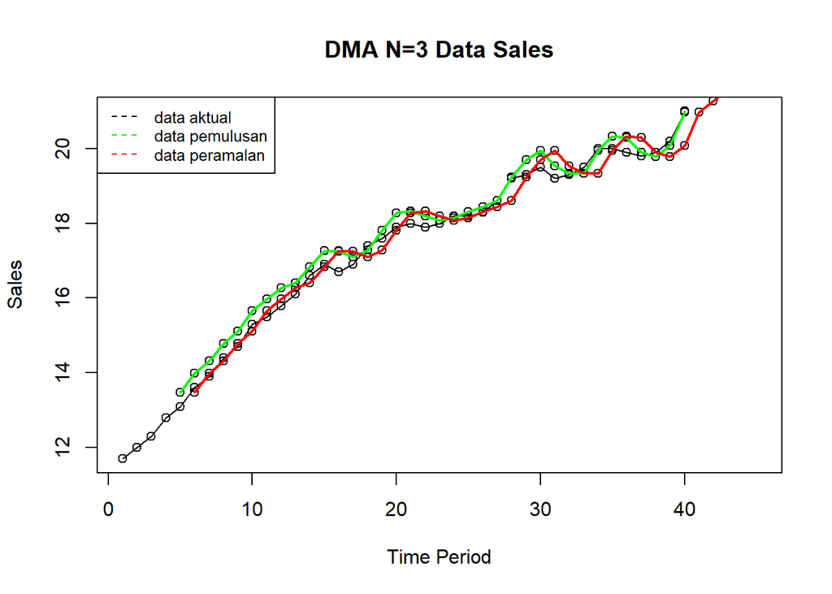

```r
#Plot Time Series
ts.plot(dt2.gab[,1],
        xlab = "Time Period",
        ylab = "Sales",
        main = "DMA N=3 Data Sales")

points(dt2.gab[,1])
points(dt2.gab[,3])
points(dt2.gab[,6])

lines(dt2.gab[,3], col = "green", lwd = 2)
lines(dt2.gab[,6], col = "red", lwd = 2)

legend("topleft",
       c("data aktual", "data pemulusan", "data peramalan"),
       lty = 8,
       col = c("black", "green", "red"),
       cex = 0.8)
```

Selanjutnya akan dilihat keakuratan dari metode DMA

```r
#Menghitung Nilai Keakuratan
error.dma2 <- dt2.ts - dt2.ramal[1:length(dt2.ts)]
SSE.dma2 <- sum(error.dma2[6:length(dt2.ts)]^2)
MSE.dma2 <- mean(error.dma2[6:length(dt2.ts)]^2)
MAPE.dma2 <- mean(abs(
  (error.dma2[6:length(dt2.ts)] / dt2.ts[6:length(dt2.ts)]) * 100
))

akurasi.dma2 <- matrix(c(SSE.dma2, MSE.dma2, MAPE.dma2))
row.names(akurasi.dma2) <- c("SSE", "MSE", "MAPE")
colnames(akurasi.dma2) <- c("Akurasi m = 3")
akurasi.dma2
```

```
##      Akurasi m = 3
## SSE      4.1285185
## MSE      0.1179577
## MAPE     1.4379655
```

Selanjutnya akan digunakan metode Double Exponential Smoothing dengan cara sebagai berikut.

Pertama akan data akan dibagi menjadi data training dan data testing.

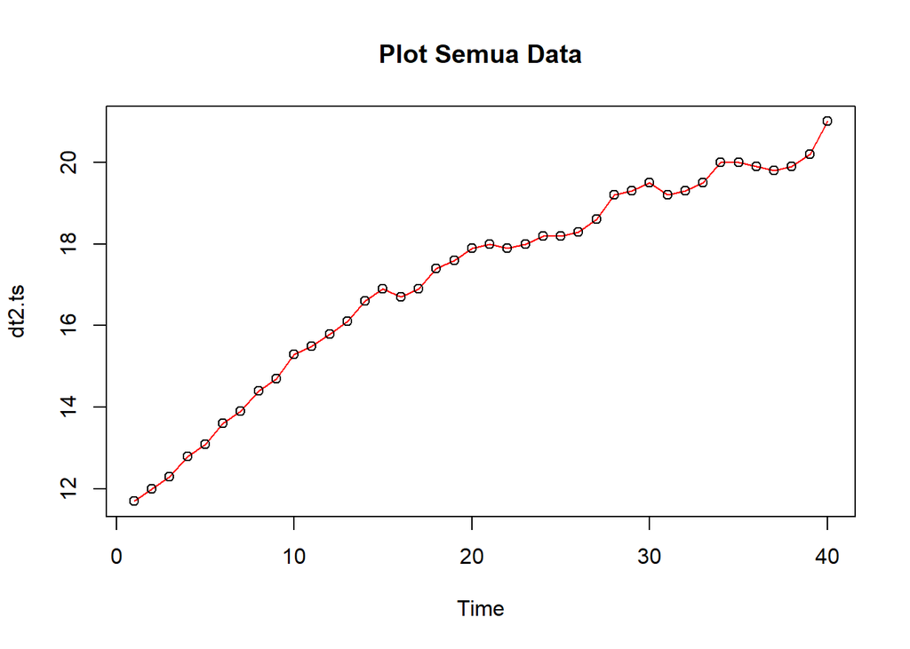

```r
#Membagi Training dan Testing
training2 <- dt2[1:10, 2]
testing2 <- dt2[11:12, 2]

#Data Time Series
training2.ts <- ts(training2)
testing2.ts <- ts(testing2, start = 11)

#Eksplorasi Data
plot(dt2.ts, col = "red", main = "Plot Semua Data")
points(dt2.ts)
```

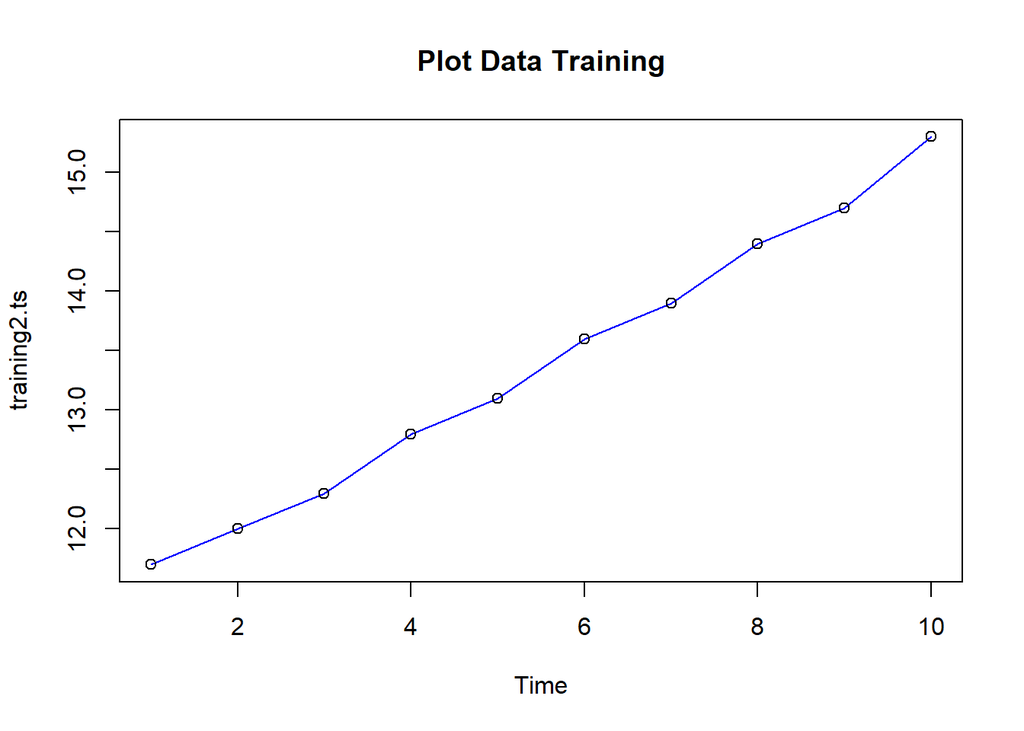

```r
plot(training2.ts, col = "blue", main = "Plot Data Training")
points(training2.ts)
```

Selanjutnya akan dilakukan pemulusan dengan DES, kali ini langsung dicari lambda dan gamma optimum sebagai berikut. Nilai lambda dan gamma optimum dapat dilihat pada smoothing parameters alpha untuk nilai lambda dan beta untuk nilai gamma.

```r
#Lambda dan Gamma Optimum
des.opt2 <- HoltWinters(training2.ts, gamma = FALSE)
des.opt2
```

```
## Holt-Winters exponential smoothing with trend and without seasonal component.
##
## Call:
## HoltWinters(x = training2.ts, gamma = FALSE)
##
## Smoothing parameters:
##  alpha: 0.3824777
##  beta : 1
##  gamma: FALSE
##
## Coefficients:
##         [,1]
## a 15.2156522
## b  0.4460783
```

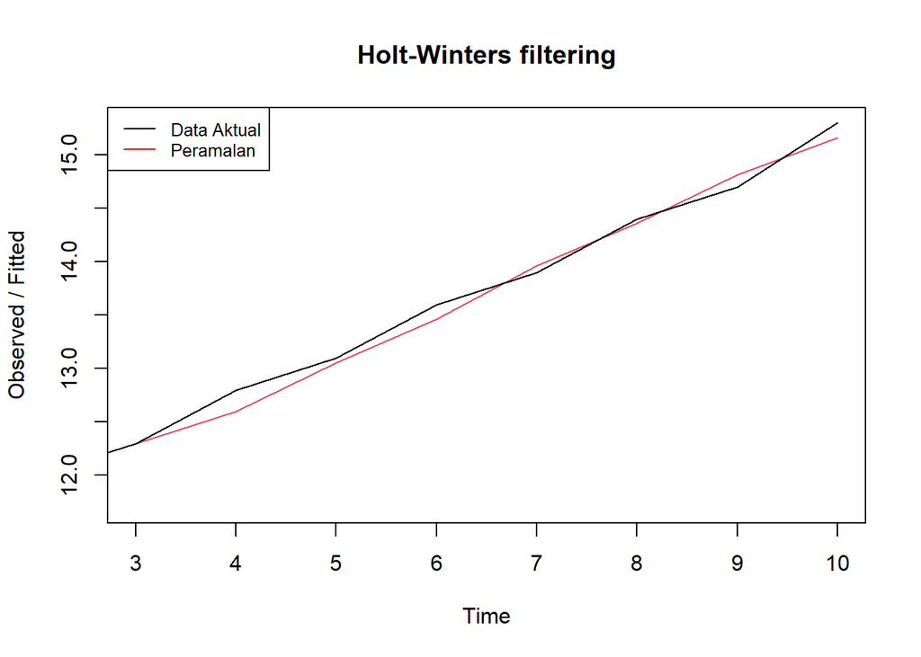

```r
plot(des.opt2)
legend("topleft",
       c("Data Aktual", "Peramalan"),
       col = c("black", "red"),
       lty = c(1,1),
       cex = 0.8)
```

```r
#Ramalan
ramalandesopt2 <- forecast(des.opt2, h = 5)
ramalandesopt2
```

```
##    Point Forecast    Lo 80    Hi 80    Lo 95    Hi 95
## 11       15.66173 15.52565 15.79781 15.45361 15.86985
## 12       16.10781 15.93648 16.27914 15.84578 16.36983
## 13       16.55389 16.32208 16.78569 16.19937 16.90840
## 14       16.99997 16.68839 17.31154 16.52346 17.47648
## 15       17.44604 17.04009 17.85200 16.82518 18.06690
```

Selanjutnya akan dicari akurasi dari metode DES.

```r
ssedes.train2 <- des.opt2$SSE
msedes.train2 <- ssedes.train2 / length(training2.ts)
sisaandes2 <- ramalandesopt2$residuals
head(sisaandes2)
```

```
## Time Series:
## Start = 1
## End = 6
## Frequency = 1
## [1]        NA        NA 0.0000000 0.2000000 0.0470089 0.1345536
```

```r
mapedes.train2 <- sum(abs(
  sisaandes2[3:length(training2.ts)] /
  training2.ts[3:length(training2.ts)]
) * 100) / length(training2.ts)

akurasides.opt2 <- matrix(c(
  ssedes.train2,
  msedes.train2,
  mapedes.train2
))
row.names(akurasides.opt2) <- c("SSE", "MSE", "MAPE")
colnames(akurasides.opt2) <- c("Akurasi lambda dan gamma optimum")
akurasides.opt2
```

```
##      Akurasi lambda dan gamma optimum
## SSE                       0.097158841
## MSE                       0.009715884
## MAPE                      0.529488796
```

```r
#Akurasi Data Testing
selisihdesopt2 <- ramalandesopt2$mean - testing2.ts
selisihdesopt2
```

```
## Time Series:
## Start = 11
## End = 12
## Frequency = 1
## [1] 0.1617304 0.3078087
```

```r
SSEtestingdesopt2 <- sum(selisihdesopt2^2)
MSEtestingdesopt2 <- SSEtestingdesopt2 / length(testing2.ts)
MAPEtestingdesopt2 <- sum(
  abs(selisihdesopt2 / testing2.ts) * 100
) / length(testing2.ts)

akurasiDesTesting2 <- matrix(
  c(SSEtestingdesopt2, MSEtestingdesopt2, MAPEtestingdesopt2)
)
row.names(akurasiDesTesting2) <- c("SSE", "MSE", "MAPE")
colnames(akurasiDesTesting2) <- c("Akurasi lambda dan gamma optimum")
akurasiDesTesting2
```

```
##      Akurasi lambda dan gamma optimum
## SSE                        0.12090296
## MSE                        0.06045148
## MAPE                       1.49578940
```

Setelah didapatkan nilai akurasi untuk metode DMA dan DES, selanjutnya akan dibandingkan keakuratan antar metode keduanya.

```r
cbind(akurasi.dma2, akurasides.opt2)
```

```
##      Akurasi m = 3 Akurasi lambda dan gamma optimum
## SSE      4.1285185                      0.097158841
## MSE      0.1179577                      0.009715884
## MAPE     1.4379655                      0.529488796
```

Berdasarkan perbandingan akurasi tersebut, terlihat nilai SSE, MSE, dan MAPE metode DES lebih kecil dibandingkan dengan metode DMA. Oleh karena itu, metode peramalan dan pemulusan yang terbaik antara keduanya adalah dengan **metode DES**.

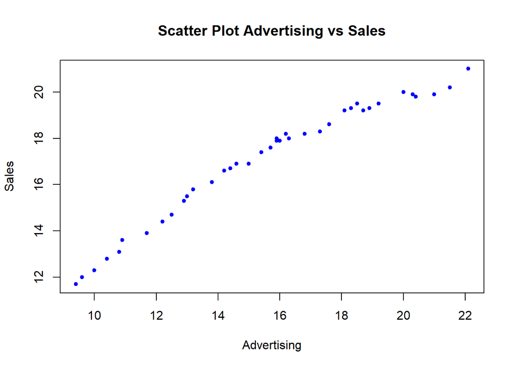

```r
#Eksplorasi Data
#Pembuatan Scatter Plot
plot(dt2$Advertising, dt2$Sales, pch = 20, col = "blue",
     main = "Scatter Plot Advertising vs Sales",
     xlab = "Advertising",
     ylab = "Sales")
```

```r
#Menampilkan Nilai Korelasi
cor(dt2$Advertising,dt2$Sales)
```

```
## [1] 0.9795849
```

Berdasarkan scatter plot di atas, terlihat adanya hubungan / korelasi positif kuat antara Advertising dengan Sales, terlihat titik-titik pada plot yang cenderung menaik ke arah kanan atas. Hal tersebut juga diperkuat dengan hasil perhitungan aplikasi R di mana didapatkan nilai korelasi sebesar 0.9795849.

Setalah mengetahui adanya hubungan antar dua peubah, maka model regresi dapat ditentukan.

## Regresi

```r
#Pembuatan Model Regresi
#Model Regresi
model2<- lm(Sales ~ Advertising, data = dt2)
summary(model2)
```

```
##
## Call:
## lm(formula = Sales ~ Advertising, data = dt2)
##
## Residuals:
##      Min       1Q   Median       3Q      Max
## -1.03758 -0.40343  0.08933  0.45674  0.74036
##
## Coefficients:
##             Estimate Std. Error t value Pr(>|t|)
## (Intercept)  5.96513    0.38092   15.66   <2e-16 ***
## Advertising  0.71035    0.02365   30.04   <2e-16 ***
## ---
## Signif. codes:  0 '***' 0.001 '**' 0.01 '*' 0.05 '.' 0.1 ' ' 1
##
## Residual standard error: 0.527 on 38 degrees of freedom
## Multiple R-squared:  0.9596, Adjusted R-squared:  0.9585
## F-statistic: 902.3 on 1 and 38 DF,  p-value: < 2.2e-16
```

Model yang dihasilkan adalah
$$y_i=
5.96513+0.71035x_i$$
Berdasarkan ringkasan model dapat diketahui bahwa hasil uji F memiliki *p-value* < $\alpha$ (5%). Artinya, minimal terdapat satu variabel yang berpengaruh nyata terhadap model. Hasil uji-t parsial kedua parameter regresi, yaitu intersep dan koefisien regresi juga menunjukkan hal yang sama, yaitu memiliki *p-value* < $\alpha$ (5%) sehingga nyata dalam taraf 5%. Selanjutnya dapat dilihat juga nilai $R^2=0.9596$. Artinya, sebesar 95.96% keragaman nilai Sales dapat dijelaskan oleh peubah Advertising. Hasil ini menunjukkan hasil yang bagus, seolah mendapatkan hasil terbaik. Namun, kita perlu melakukan uji terhadap sisaannya seperti berikut ini.

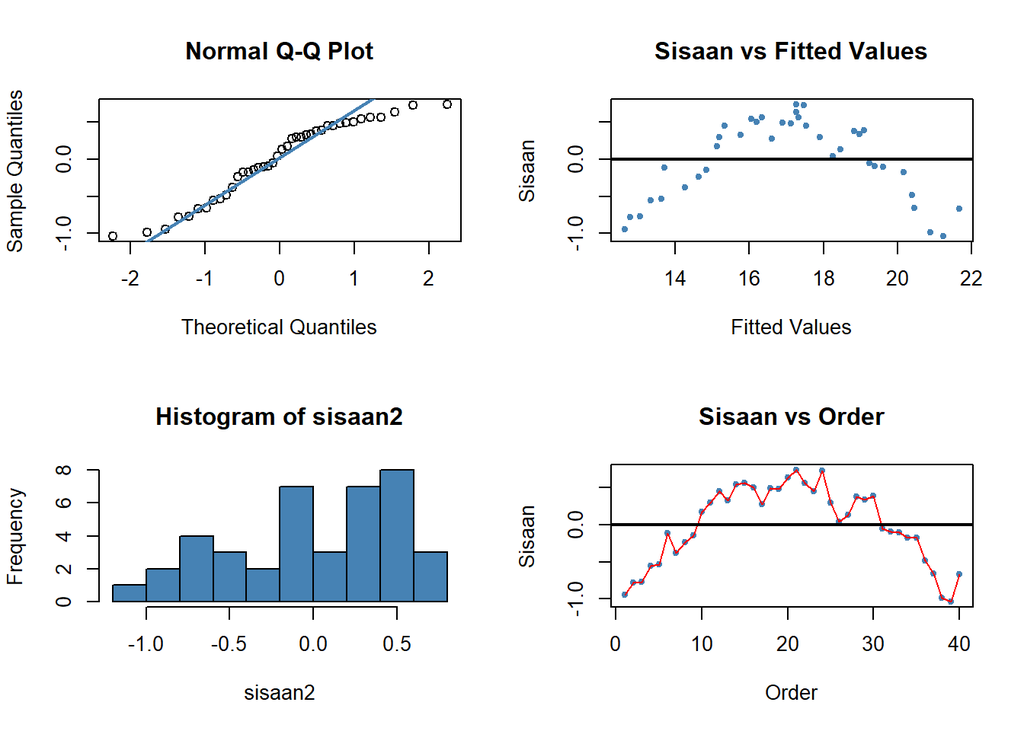

```r
#Sisaan dan Fitted Value
sisaan2 <- residuals(model2)
fitValue2 <- predict(model2)

#Diagnostik dengan Eksploratif
par(mfrow = c(2,2))
qqnorm(sisaan2)
qqline(sisaan2, col = "steelblue", lwd = 2)
plot(fitValue2, sisaan2, col = "steelblue", pch = 20,
     xlab = "Fitted Values", ylab = "Sisaan",
     main = "Sisaan vs Fitted Values")
abline(a = 0, b = 0, lwd = 2)
hist(sisaan2, col = "steelblue")
plot(1:length(sisaan2), sisaan2, col = "steelblue", pch = 20,
     xlab = "Order", ylab = "Sisaan",
     main = "Sisaan vs Order")
lines(1:length(sisaan2), sisaan2, col = "red")
abline(a = 0, b = 0, lwd = 2)
```

```r
#Melihat Sisaan Menyebar Normal/Tidak
#H0: sisaan mengikuti sebaran normal
#H1: sisaan tidak mengikuti sebaran normal
shapiro.test(sisaan2)
```

```
##
##  Shapiro-Wilk normality test
##
## data:  sisaan2
## W = 0.93205, p-value = 0.0188
```

```r
ks.test(sisaan2, "pnorm", mean = mean(sisaan2), sd = sd(sisaan2))
```

```
##
##  Asymptotic one-sample Kolmogorov-Smirnov test
##
## data:  sisaan2
## D = 0.15458, p-value = 0.2948
## alternative hypothesis: two-sided
```

Berdasarkan uji formal Saphiro-Wilk didapatkan nilai *p-value* < $\alpha$ (5%) sementara pada uji Kolmogorov-Smirnov didapatkan nilai *p-value* > $\alpha$ (5%). Artinya, pada uji Shapiro-Wilk tolak $H_0$ sehingga terdapat cukup bukti bahwa sisaan tidak berdistribusi normal. Sebaliknya, pada uji Kolmogorov-Smirnov gagal tolak $H_0$ sehingga terdapat cukup bukti untuk menyatakan bahwa sisaan berdistribusi normal. Dengan demikian, kedua uji formal memberikan hasil yang berbeda dalam menguji normalitas sisaan.

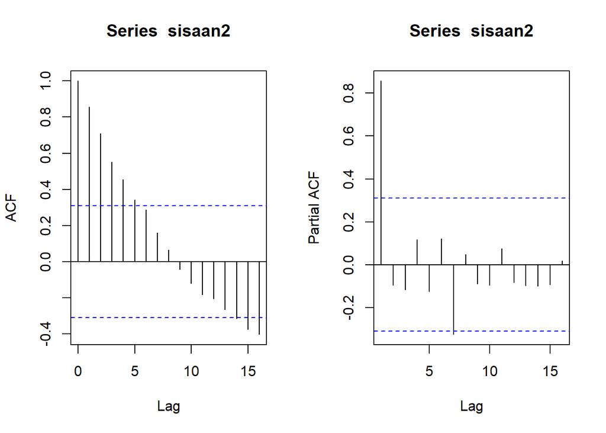

```r
#ACF dan PACF Identifikasi Autokorelasi
par(mfrow = c(1,2))
acf(sisaan2)
pacf(sisaan2)
```

Berdasarkan plot ACF dan PACF, terlihat terdapat beberapa lag yang melewati rentang batas sehingga terdapat lag yang signifikan. Hal ini menunjukkan adanya indikasi autokorelasi pada sisaan. Namun, untuk lebih memastikan akan dilakukan uji formal dengan uji Durbin Watson.

```r
#Deteksi Autokorelasi dengan Uji-Durbin Watson
#H0: tidak ada autokorelasi
#H1: ada autokorelasi
dwtest(model2)
```

```
##
##  Durbin-Watson test
##
## data:  model2
## DW = 0.16204, p-value < 2.2e-16
## alternative hypothesis: true autocorrelation is greater than 0
```

Berdasarkan hasil DW Test, didapatkan nilai $DW = 0.16204$ dan *p-value* $< 2.2e-16$. Berdasarkan tabel Durbin-Watson diperoleh nilai $DL = 1.4421$ dan $DU = 1.5444$. Nilai DW berada di rentang 0 < DW < DL (0 < $0.16204$ < $1.4421$). Berdasarkan kriteria Durbin-Watson dapat disimpulkan bahwa terdapat autokorelasi positif. Namun, dengan nilai *p-value* < 0.05 dapat disimpulkan bahwa tolak H0, sehingga terdapat cukup bukti untuk mengatakan adanya autokorelasi. Oleh karena itu, diperlukan penanganan autokorelasi. Penanganan yang akan digunakan menggunakan dua metode, yaitu Cochrane-Orcutt dan Hildret-Lu.

## Penanganan Autokorelasi

### Metode Cochrane-Orcutt

Penanganan metode Cochrane-Orcutt dapat dilakukan dengan bantuan packages Orcutt pada aplikasi `R` maupun secara manual. Berikut ini ditampilkan cara menggunakan bantuan `library` *packages* `Orcutt`.

```r
#Penanganan Autokorelasi Cochrane-Orcutt
modelCO2 <- cochrane.orcutt(model2)
modelCO2
```

```
## Cochrane-orcutt estimation for first order autocorrelation
##
## Call:
## lm(formula = Sales ~ Advertising, data = dt2)
##
##  number of interaction: 39
##  rho 0.903123
##
## Durbin-Watson statistic
## (original):    0.16204 , p-value: 8.935e-20
## (transformed): 1.93925 , p-value: 3.78e-01
##
##  coefficients:
## (Intercept) Advertising
##   10.252375    0.488489
```

Hasil keluaran model setelah dilakukan penanganan adalah sebagai berikut.
$$y_i=10.252375+0.488489x_i$$
Hasil juga menunjukkan bahwa nilai DW dan p-value meningkat menjadi $1.93925$ dan $0.378$. Nilai DW sudah berada pada rentang DU < DW < 4-DU atau $1.5444 < DW < 2.4556$. Hal tersebut juga didukung dengan nilai *p-value* > 0.05, artinya belum cukup bukti untuk menyatakan bahwa terdapat autokorelasi pada sisaan pada taraf nyata 5%. Untuk nilai $ρ ̂$ optimum yang digunakan adalah $0.903123$. Nilai tersebut dapat diketahui dengan *syntax* berikut.

```r
#Rho Optimum
rho2 <- modelCO2$rho
rho2
```

```
## [1] 0.9031233
```

Selanjutnya akan dilakukan transformasi secara manual dengan syntax berikut ini.

```r
dt2$Sales
```

```
##  [1] 11.7 12.0 12.3 12.8 13.1 13.6 13.9 14.4 14.7 15.3 15.5 15.8 16.1 16.6 16.9
## [16] 16.7 16.9 17.4 17.6 17.9 18.0 17.9 18.0 18.2 18.2 18.3 18.6 19.2 19.3 19.5
## [31] 19.2 19.3 19.5 20.0 20.0 19.9 19.8 19.9 20.2 21.0
```

```r
dt2$Sales[-1]
```

```
##  [1] 12.0 12.3 12.8 13.1 13.6 13.9 14.4 14.7 15.3 15.5 15.8 16.1 16.6 16.9 16.7
## [16] 16.9 17.4 17.6 17.9 18.0 17.9 18.0 18.2 18.2 18.3 18.6 19.2 19.3 19.5 19.2
## [31] 19.3 19.5 20.0 20.0 19.9 19.8 19.9 20.2 21.0
```

```r
#Transformasi Manual
sales.trans <- dt2$Sales[-1] -
               dt2$Sales[-length(dt2$Sales)] * rho2
advertising.trans <- dt2$Advertising[-1] -
                     dt2$Advertising[-length(dt2$Advertising)] * rho2

modelCOmanual2 <- lm(sales.trans ~ advertising.trans)
summary(modelCOmanual2)
```

```
##
## Call:
## lm(formula = sales.trans ~ advertising.trans)
##
## Residuals:
##      Min       1Q   Median       3Q      Max
## -0.37730 -0.14957  0.01257  0.10464  0.45315
##
## Coefficients:
##                   Estimate Std. Error t value Pr(>|t|)
## (Intercept)        0.99322    0.14141   7.023 2.64e-08 ***
## advertising.trans  0.48849    0.07543   6.476 1.43e-07 ***
## ---
## Signif. codes:  0 '***' 0.001 '**' 0.01 '*' 0.05 '.' 0.1 ' ' 1
##
## Residual standard error: 0.1868 on 37 degrees of freedom
## Multiple R-squared:  0.5313, Adjusted R-squared:  0.5186
## F-statistic: 41.94 on 1 and 37 DF,  p-value: 1.426e-07
```

```r
#Mencari Penduga Koefisien Regresi setelah Transformasi ke Persamaan Awal
b0bintang2 <- modelCOmanual2$coefficients[-2]
b0_2 <- b0bintang2 / (1 - rho2)
b1_2 <- modelCOmanual2$coefficients[-1]
b0_2
```

```
## (Intercept)
##    10.25237
```

```r
b1_2
```

```
## advertising.trans
##         0.4884891
```

Hasil perhitungan koefisien regresi tersebut akan menghasilkan hasil yang sama dengan model yang dihasilkan menggunakan *packages*.

### Metode Hildreth-Lu

Penanganan kedua adalah menggunakan metode Hildreth-Lu. Metode ini akan mencari nilai SSE terkecil dan dapat dicari secara manual maupun menggunakan packages. Jika menggunakan packages, gunakan `library` *packages* `HORM`.

```r
library(HoRM)

# Ambil y dan x (satu prediktor saja)
y2 <- dt2$Sales
x2 <- dt2$Advertising

# Grid search rho 0–0.9
r2 <- seq(0, 0.9, by = 0.1)

tab2 <- data.frame(
  rho = r2,
  SSE = sapply(r2, function(rr) deviance(hildreth.lu(y2, x2, rr)))
)

tab2             # tabel rho vs SSE
```

```
##    rho      SSE
## 1  0.0 9.561851
## 2  0.1 7.845710
## 3  0.2 6.330287
## 4  0.3 5.015381
## 5  0.4 3.900668
## 6  0.5 2.985599
## 7  0.6 2.269173
## 8  0.7 1.749430
## 9  0.8 1.422573
## 10 0.9 1.291395
```

```r
rho_hat2 <- tab2$rho[which.min(tab2$SSE)]   # rho terbaik
fit_hl2 <- hildreth.lu(y2, x2, rho_hat2)    # model final

summary(fit_hl2)
```

```
##
## Call:
## lm(formula = y ~ x)
##
## Residuals:
##     Min      1Q  Median      3Q     Max
## -0.3749 -0.1461  0.0148  0.1057  0.4496
##
## Coefficients:
##             Estimate Std. Error t value Pr(>|t|)
## (Intercept)  1.01310    0.14198   7.135 1.87e-08 ***
## x            0.49358    0.07379   6.689 7.38e-08 ***
## ---
## Signif. codes:  0 '***' 0.001 '**' 0.01 '*' 0.05 '.' 0.1 ' ' 1
##
## Residual standard error: 0.1868 on 37 degrees of freedom
## Multiple R-squared:  0.5474, Adjusted R-squared:  0.5351
## F-statistic: 44.74 on 1 and 37 DF,  p-value: 7.382e-08
```

```r
# Penanganan Autokorelasi Hildreth-Lu
# Hildreth-Lu
hildreth.lu.func2 <- function(r, model){
  x <- model.matrix(model)[,-1]
  y <- model.response(model.frame(model))
  n <- length(y)
  t <- 2:n
  y <- y[t] - r*y[t-1]
  x <- x[t] - r*x[t-1]

  return(lm(y ~ x))
}

# Pencarian rho yang meminimumkan SSE
r2 <- c(seq(0.1, 0.9, by = 0.1))
tab2 <- data.frame(
  "rho" = r2,
  "SSE" = sapply(r2, function(i) {
    deviance(hildreth.lu.func2(i, model2))
  })
)
round(tab2, 4)
```

```
##   rho    SSE
## 1 0.1 7.8457
## 2 0.2 6.3303
## 3 0.3 5.0154
## 4 0.4 3.9007
## 5 0.5 2.9856
## 6 0.6 2.2692
## 7 0.7 1.7494
## 8 0.8 1.4226
## 9 0.9 1.2914
```

```r
# Rho optimal di sekitar 0.9
rOpt2 <- seq(0.8, 0.999, by = 0.001)
tabOpt2 <- data.frame(
  "rho" = rOpt2,
  "SSE" = sapply(rOpt2, function(i) {
    deviance(hildreth.lu.func2(i, model2))
  })
)
head(tabOpt2[order(tabOpt2$SSE),])
```

```
##       rho      SSE
## 104 0.903 1.291226
## 105 0.904 1.291239
## 103 0.902 1.291248
## 106 0.905 1.291289
## 102 0.901 1.291304
## 107 0.906 1.291375
```

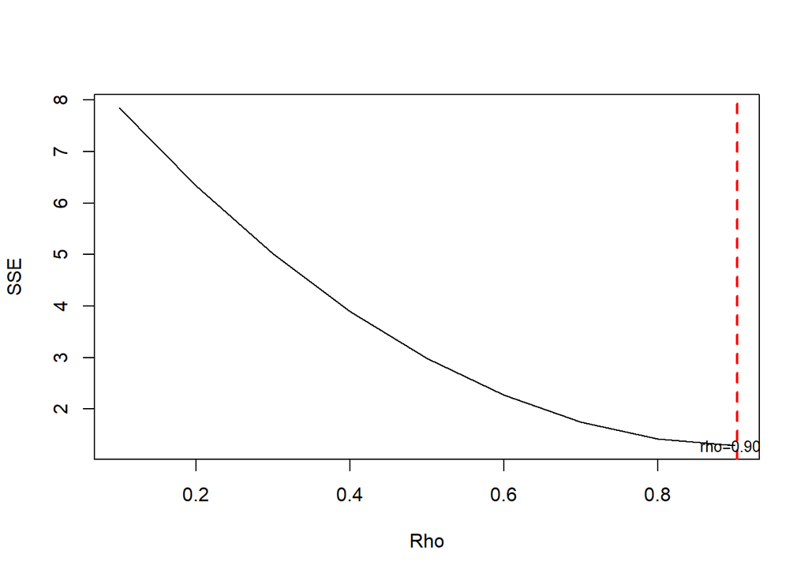

```r
# Grafik SSE optimum
par(mfrow = c(1,1))
plot(tab2$SSE ~ tab2$rho,
     type = "l",
     xlab = "Rho",
     ylab = "SSE")
abline(v = tabOpt2[tabOpt2$SSE == min(tabOpt2$SSE), "rho"],
       lty = 2, col = "red", lwd = 2)
text(x = 0.9,
     y = min(tabOpt2$SSE),
     labels = paste0("rho=",
                     tabOpt2[which.min(tabOpt2$SSE), "rho"]),
     cex = 0.8)
```

Perhitungan yang dilakukan aplikasi `R` menunjukkan bahwa nilai $ρ$ optimum, yaitu saat SSE terkecil terdapat pada nilai $ρ=0.903$. Hal tersebut juga ditunjukkan pada plot. Selanjutnya, model dapat didapatkan dengan mengevaluasi nilai $ρ$ ke dalam fungsi `hildreth.lu.func2`, serta dilanjutkan dengan pengujian autokorelasi dengan uji Durbin-Watson. Namun, setelah pengecekan tersebut tidak lupa koefisien regresi tersebut digunakan untuk transformasi balik. Persamaan hasil transformasi itulah yang menjadi persamaan sesungguhnya.

```r
#Model Terbaik
modelHL2 <- hildreth.lu.func2(0.903, model2)
summary(modelHL2)
```

```
##
## Call:
## lm(formula = y ~ x)
##
## Residuals:
##      Min       1Q   Median       3Q      Max
## -0.37720 -0.14949  0.01266  0.10464  0.45301
##
## Coefficients:
##             Estimate Std. Error t value Pr(>|t|)
## (Intercept)  0.99401    0.14144   7.028 2.60e-08 ***
## x            0.48869    0.07536   6.485 1.39e-07 ***
## ---
## Signif. codes:  0 '***' 0.001 '**' 0.01 '*' 0.05 '.' 0.1 ' ' 1
##
## Residual standard error: 0.1868 on 37 degrees of freedom
## Multiple R-squared:  0.532,  Adjusted R-squared:  0.5193
## F-statistic: 42.05 on 1 and 37 DF,  p-value: 1.39e-07
```

```r
#Transformasi Balik
cat("y = ", coef(modelHL2)[1]/(1-0.903), "+", coef(modelHL2)[2], "x", sep = "")
```

```
## y = 10.24749+0.4886925x
```

Setelah dilakukan tranformasi balik, didapatkan model dengan metode Hildreth-Lu sebagai berikut.
$$y_i=10.24749+0.4886925x_i$$

```r
#Deteksi Autokorelasi
dwtest(modelHL2)
```

```
##
##  Durbin-Watson test
##
## data:  modelHL2
## DW = 1.9393, p-value = 0.378
## alternative hypothesis: true autocorrelation is greater than 0
```

Hasil uji Durbin-Watson juga menunjukkan bawah nilai DW sebesar $1.9393$ berada pada selang daerah tidak ada autokorelasi, yaitu pada rentang DU < DW < 4-DU atau $1.5444 < DW < 2.4556$. Hal tersebut juga didukung oleh *p-value* sebesar $0.378$, di mana *p-value* > $\alpha$=5%. Artinya tak tolak $H_0$ atau belum cukup bukti untuk menyatakan bahwa terdapat autokorelasi dalam data nilai Sales dengan metode Hildreth-Lu pada taraf nyata 5%.

Terakhir, akan dibandingkan nilai SSE dari ketiga metode (metode awal, metode Cochrane-Orcutt, dan Hildreth-Lu).

```r
#Perbandingan
sseModelawal2 <- anova(model2)$`Sum Sq`[-1]
sseModelCO2 <- anova(modelCOmanual2)$`Sum Sq`[-1]
sseModelHL2 <- anova(modelHL2)$`Sum Sq`[-1]
mseModelawal2 <- sseModelawal2 / length(dt2$Sales)
mseModelCO2 <- sseModelCO2 / length(dt2$Sales)
mseModelHL2 <- sseModelHL2 / length(dt2$Sales)
akurasi2 <- matrix(
  c(sseModelawal2, sseModelCO2, sseModelHL2,
    mseModelawal2, mseModelCO2, mseModelHL2),
  nrow = 2, ncol = 3, byrow = T
)
colnames(akurasi2) <- c(
  "Model Awal",
  "Model Cochrane-Orcutt",
  "Model Hildreth-Lu"
)
row.names(akurasi2) <- c("SSE", "MSE")
akurasi2
```

```
##     Model Awal Model Cochrane-Orcutt Model Hildreth-Lu
## SSE 10.5545322            1.29122545        1.29122572
## MSE  0.2638633            0.03228064        0.03228064
```

Berdasarkan hasil tersebut dapat diketahui bahwa hasil penanganan autokorelasi dengan metode Cochrane-Orcutt dan Hildreth-Lu memiliki SSE yang hampir sama, yaitu masing-masing sebesar $1.29122545$ dan $1.29122572$, serta lebih baik dibandingkan model awal ketika autokorelasi masih terjadi, yaitu sebesar $10.5545322$.

## Simpulan

Autokorelasi yang terdapat pada data Sales terjadi akibat adanya korelasi di antara unsur penyusunnya. Indikator Sales yang erat hubungannya dengan perekonomian sangat rawan menjadi penyebab adanya autokorelasi. Adanya autokorelasi menyebabkan model regresi kurang baik karena akan meningkatkan galatnya. Autokorelasi dapat dideteksi secara eksploratif melalui plot sisaan, ACF, dan PACF, serta dengan uji formal Durbin-Watson. Namun, autokorelasi tersebut dapat ditangani dengan metode Cochrane-Orcutt dan Hildreth-Lu. Kedua metode menghasilkan nilai SSE yang hampir sama, sehingga keduanya dapat digunakan untuk menangani autokorelasi pada data.